# HW 5

Wenjuan Bian

08032023

Provide your answers and relevant outputs below each question in this markdown file and submit the knitted `html` or `pdf` file to Canvas. Put your answers/comments/conclusions in **bold**.

##### Scalar-on-function GLM

Suppose we simulate 250 independent 2D point clouds, where each point cloud consists of 50 points sampled uniformly from the *unit circle* (shape 1) with some Gaussian noise added to the x and y coordinates. In a similar fashion, we simulate another 250 independent point clouds sampled from *two concentric circles with radii 0.9 and 1.1* (shape 2). The response variable $Y_i$ is binary: $Y_i=0$ if the point cloud is sampled from shape 1 and $Y_i=1$ if sampled from shape 2 ($i=1,2,\dots,500$). The shapes of the point clouds can be described by two functions $X_{1i}(t)$ and $X_{2i}(t)$, called *persistence silhouettes* (of homological dimensions $H_0$ and $H_1$). The goal is to build a *scalar-on-function* GLM to predict $Y_i$ (shape 1 or 2) using persistence silhouette functions either $X_{1i}(t)$ or $X_{2i}(t)$ (but not both).

The files `P2Ytrain.csv` and `P2Ytest.csv` contain 500 observed values of $Y_i$ of the train and test datasets respectively. `P2X1train.csv` and `P2X2train.csv` store the values of $X_{1i}(t)$ and $X_{2i}(t)$ observed at 100 equally spaced points $t_j$, $j=1,2,\ldots,100$ for the training set. Similarly, `P2X1test.csv` and `P2X2test.csv` contain the test data.

1. Using `matplot()` function (with type=‘l’ inside of it), plot the raw values of $X_{1i}(t)$ and $X_{2i}(t)$ for the training set. Color the curves based on the shape type (shape 1 or shape 2). Looking at the plots, which of the two sets of curves is more informative to distinguish the two shapes?

```r
library(fda)
```

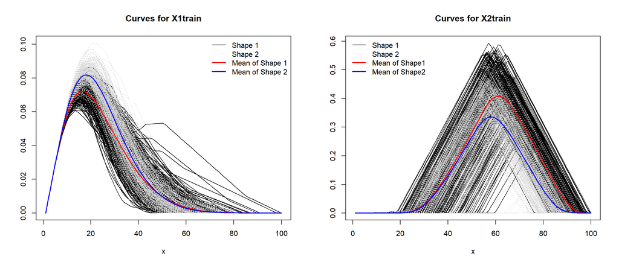

```r
library(refund)
# Read the training data
# Read the training data
path_Ytrain <- "C:/Users/fwjbi/OneDrive - Bowling Green State University/Summer 2023/6820-Function/Chapter 6/data/P2Ytrain.csv"
path_X1train <- "C:/Users/fwjbi/OneDrive - Bowling Green State University/Summer 2023/6820-Function/Chapter 6/data/P2X1train.csv"
path_X2train <- "C:/Users/fwjbi/OneDrive - Bowling Green State University/Summer 2023/6820-Function/Chapter 6/data/P2X2train.csv"
path_X1test <- "C:/Users/fwjbi/OneDrive - Bowling Green State University/Summer 2023/6820-Function/Chapter 6/data/P2X1test.csv"
path_Ytest <- "C:/Users/fwjbi/OneDrive - Bowling Green State University/Summer 2023/6820-Function/Chapter 6/data/P2Ytest.csv"
path_X2test <- "C:/Users/fwjbi/OneDrive - Bowling Green State University/Summer 2023/6820-Function/Chapter 6/data/P2X2test.csv"

Ytrain <- read.csv(path_Ytrain)
X1train <- read.csv(path_X1train)
X2train <- read.csv(path_X2train)
X1test <- read.csv(path_X1test)
X2test <- read.csv(path_X2test)
Ytest <- read.csv(path_Ytest)

colors <- ifelse(Ytrain$x == 0, "black", "lightgray")
line_types <- ifelse(Ytrain$x == 0, 1, 3)

means1 <- sapply(X1train[Ytrain$x == 0, ], mean)
means2 <- sapply(X1train[Ytrain$x == 1, ], mean)
means3 <- sapply(X2train[Ytrain$x == 0, ], mean)
means4 <- sapply(X2train[Ytrain$x == 1, ], mean)

par(mfrow = c(1, 2))
# First plot
matplot(t(X1train), type = 'l', col = colors, lty = line_types, main = "Curves for X1train")
lines(means1, col = "red", lwd = 2)
lines(means2, col = "blue", lwd = 2)
legend("topright", legend = c("Shape 1", "Shape 2", "Mean of Shape 1", "Mean of Shape 2"),
       col = c("black", "lightgray", "red", "blue"), lty = c(1, 3, 1, 1), lwd = c(1, 1, 2, 2), bty = "n")

# Second plot
matplot(t(X2train), type = 'l', col = colors, lty = line_types, main = "Curves for X2train")
lines(means3, col = "red", lwd = 2)
lines(means4, col = "blue", lwd = 2)
legend("topleft", legend = c("Shape 1", "Shape 2", "Mean of Shape1", "Mean of Shape2"),
       col = c("black", "lightgray", "red", "blue"), lty = c(1, 3, 1, 1), lwd = c(1, 1, 2, 2), bty = "n")
```

```r
par(mfrow = c(1, 1))
```

2. Using the `pfr()` (with `lf()` inside of it) function fit a regression model with $X_{1i}(t)$ as the input functional predictor. Use the *logit* as your link function. Let the number of basis functions, $k$, vary from 4 to 7 and choose its optimal value based on the AIC score. Set `fx=TRUE` inside `lf()` and use the default settings for the other arguments. Your final model is the model fit with the optimal value of $k$.
3. Plot the graph of the estimated coefficient function $\hat \beta(t)$.

```r
X = as.matrix(X1train)
X2 = as.matrix(X2train)
Xtest = as.matrix(X1test)
Xtest2 = as.matrix(X2test)


aic_all1 = numeric(0)
k_all1 = 4:7
for(k in k_all1){
  fit1 <- pfr(Ytrain ~ lf(X, k = k, fx = TRUE), family = binomial(link = "logit"))
  tmp1 = extractAIC(fit1)[2]
  aic_all1 = c(aic_all1,tmp1)
}


k_opt1 <- k_all1[which.min(aic_all1)]
k_opt1
```

```
## [1] 7
```

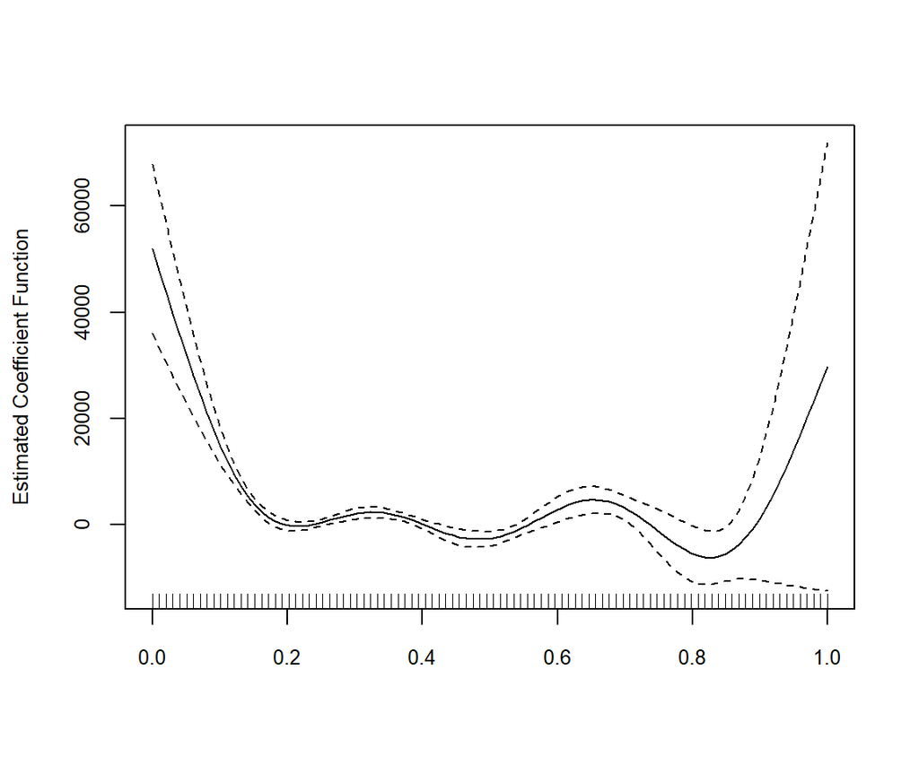

```r
fit.f1 <- pfr(Ytrain ~ lf(X, k = k_opt1, fx = TRUE), family = binomial(link = "logit"))
# summary(fit.f1)
# str(fit.f1)
plot(fit.f1, xlab="", ylab="Estimated Coefficient Function", cex.lab=0.8, cex.axis=0.8)
```

4. Use the `predict()` function (with type = ‘response’ inside of it) to compute $P(Y_i=1)$ (probability that a given curve corresponds to shape 2) on the test set. Convert these probabilities into binary outcome of 0 (shape 1) and 1 (shape 2) using the 0.5 probability threshold. Finally, compute and report the *accuracy* of your final model on the test set.

```r
predictions1 <- predict(fit.f1, newdata = list(X = Xtest), type = "response")
pred1 <- ifelse(predictions1 > 0.5, 1, 0)

dfp1 <- data.frame(Preds1 = pred1, Obs1 = Ytest)
dfp1$Correct <- dfp1$Preds1 == dfp1$x
Accuracy1 <-sum(dfp1$Correct)/length(dfp1$Correct)
Accuracy1
```

```
## [1] 0.546
```

5. Repeat (b)-(d) for $X_{2i}(t)$.

```r
aic_all2 = numeric(0)
k_all2 = 4:7
for(k in k_all1){
  fit2 <- pfr(Ytrain ~ lf(X2, k = k, fx = TRUE), family = binomial(link = "logit"))
  tmp2 = extractAIC(fit2)[2]
  aic_all2 = c(aic_all2,tmp2)
}


k_opt2 <- k_all2[which.min(aic_all2)]
k_opt2
```

```
## [1] 5
```

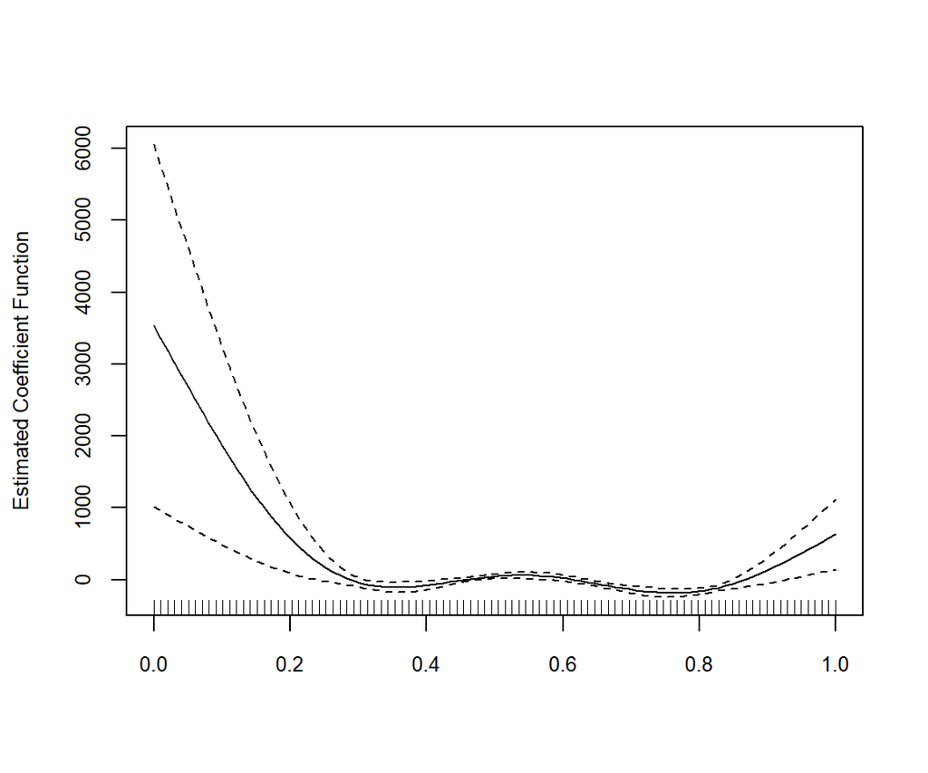

```r
fit.f2 <- pfr(Ytrain ~ lf(X2, k = k_opt2, fx = TRUE), family = binomial(link = "logit"))
# summary(fit.f2)
plot(fit.f2, xlab="", ylab="Estimated Coefficient Function",cex.lab=0.8, cex.axis=0.8)
```

```r
predictions2 <- predict(fit.f2, newdata = list(X2 = Xtest2), type = "response")
pred2 <- ifelse(predictions2 > 0.5, 1, 0)

dfp2 <- data.frame(Preds2 = pred2, Obs2 = Ytest)
dfp2$Correct <- dfp2$Preds2 == dfp2$x
Accuracy2 <-sum(dfp2$Correct)/length(dfp2$Correct)
Accuracy2
```

```
## [1] 0.826
```

6. Which of the two models provides the lowest test accuracy?

**Model 1 has an accuracy rate of 0.546, whereas Model 2 has a higher accuracy rate of 0.826. Therefore, Model 1 provides the lower test accuracy of the two.**